# Agenda Bias 2

Control for topical prevalence

To allow for an operationalization of agenda bias, I use parties’ campaign communication as an approximation of the potential universe of news stories (D’Alessio & Allen, 2000; Eberl, 2017). I compare the policy issues addressed in campaign communication (i.e., the party agenda) with the policy issues the parties address in media coverage (i.e., the mediated party agenda).

To discover the latent topics in the corpus of press releases (1.942) and news articles (11.880), a structural topic modeling (STM) developed by [Roberts (2016)](https://scholar.princeton.edu/sites/default/files/bstewart/files/a_model_of_text_for_experimentation_in_the_social_sciences.pdf) is applied. The STM is an unsupervised machine learning approach that models topics as multinomial distributions of words and documents as multinomial distributions of topics, allowing to incorporate external variables that effect both, topical content and topical prevalence.

# Structural Topic Model

## Build Corpus

I included the document source as a control for the topical topical prevalenc. Thus, I assume that the distribution of topics depends on the source. The number of topics is set to 40.

## Run Model

```r
k=40

stmOut <- stm(documents = out$documents, vocab = out$vocab,
              K = k, prevalence =~ source,
              max.em.its = 75, data = out$meta,
              init.type = "Spectral")

save(model_df, out, stmOut, file = "../output/models/finalmodel_40.Rda")
```

## Results

```r
library(stm)
library(tidyverse)
rm(list = ls())
source("func/functions.R")
load("../output/models/finalmodel_40.RData")
model_df <- model_df %>%
  mutate(doc_index = as.numeric(rownames(.)))
```

```r
## Label topics
labels <- labelTopics(stmOut)
topics.df <- as.data.frame(labels$prob) %>%
  transmute(topic = as.numeric(rownames(.)),
            topic_name = paste("Topic",as.character(topic),":",V1,V2,V3,V4))
```

### Topic frequency

In order to get an initial overview of the results, the figure below displays the topics ordered by their expected frequency across the corpus. The four most frequent words in each topic are used as a label for that topic.

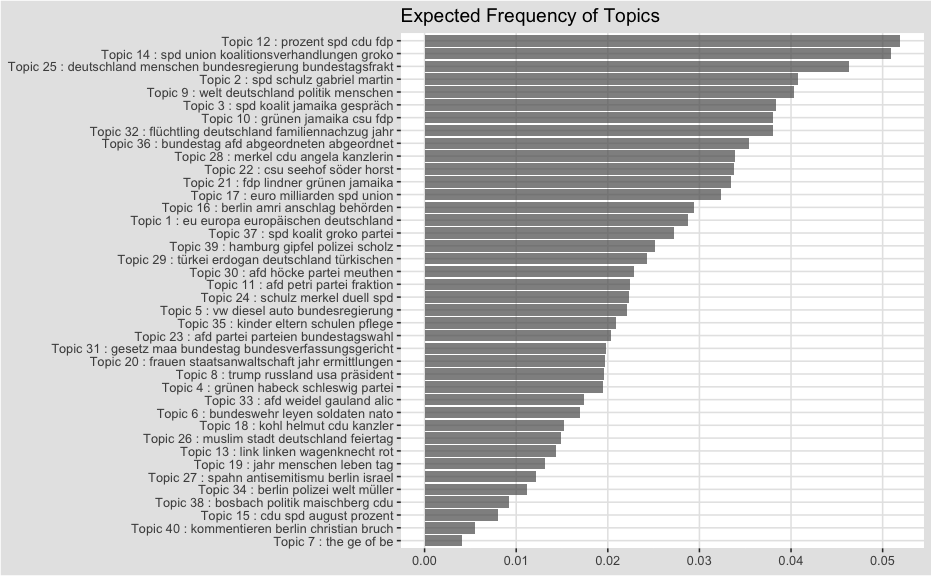

```r
overall_freq %>%
  ggplot(aes(reorder(topic_name, -order), frequency)) +
  geom_col(alpha = 0.7) +
  coord_flip() +
  ggthemes::theme_igray() +
  labs(x=NULL, y=NULL, title="Expected Frequency of Topics")
```

### Measure Agendas

```r
theta <- as.data.frame(stmOut$theta) %>% # get all theta values for echt document

  mutate(doc_index = as.numeric(rownames(.))) %>%
  # convert to long format
  gather(topic, theta, V1:V40) %>%
  mutate(topic = as.numeric(gsub("V","",topic))) %>%

  # join with topic df
  left_join(., topics.df, by="topic") %>%

  # join with model_df
  left_join(., model_df %>%
              select(date,type,source,doc_index,title_text), by="doc_index")
```

For each document, we have a distribution over all topics:

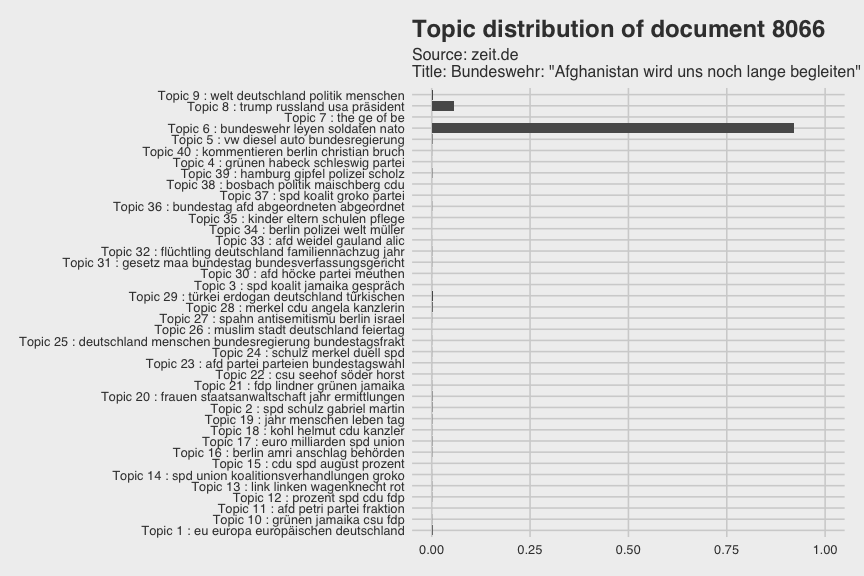

```r
sample_doc <- sample(nrow(model_df),1)
# uncomment this to only select docs from press releases
#sample_doc <- theta %>% filter(type=="press") %>% sample_n(1) %>% select(doc_index)
#sample_doc <- sample_doc$doc_index
title <- model_df$title[which(model_df$doc_index == sample_doc)]
source <- model_df$source[which(model_df$doc_index == sample_doc)]
theta %>%
  filter(doc_index == sample_doc) %>%
  select(doc_index, topic_name, theta) %>%
  ggplot(aes(topic_name, theta)) +
  geom_col() +
  ylim(c(0,1)) +
  coord_flip() +
  ggthemes::theme_fivethirtyeight() +
  labs(title = paste("Topic distribution of document",sample_doc),
       subtitle = paste0("Source: ",source,"\nTitle: ", title),
       x = NULL, y = NULL
       )
```

What is the document acutally about?

```r
model_df %>%
  filter(doc_index == sample_doc) %>%
  select(source, title_text) %>%
  htmlTable::htmlTable()
```

|  | source | title_text |
| --- | --- | --- |
| 1 | zeit.de | Bundeswehr: "Afghanistan wird uns noch lange begleiten" Die internationalen Truppen hätten sich zu schnell aus Afghanistan zurück gezogen, bemängelt Verteidigungsministerin von der Leyen. Sie fordert … |

Agendas were measured in terms of percentage distributions across the 40 topics. For each source the average distribution of each topic is calculated.

```r
topicmean <- theta %>%
  group_by(topic,topic_name, source) %>%
  summarise(topicmean = mean(theta)) %>%
  ungroup()
```

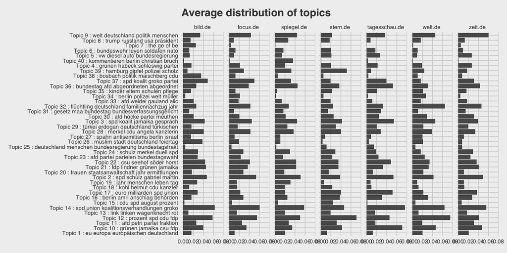

```r
topicmean_news <- theta %>%
  filter(type == "news") %>%
  group_by(topic,topic_name, source) %>%
  summarise(topicmean = mean(theta)) %>%
  ungroup()
topicmean_news %>%
  ggplot(aes(topic_name,topicmean)) +
  geom_col() +
  coord_flip() +
  ggthemes::theme_fivethirtyeight() +
  facet_grid(~source) +
  labs(x=NULL, y=NULL, title="Average distribution of topics")
```

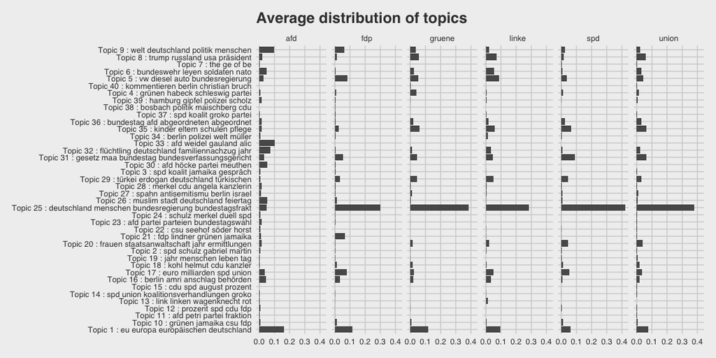

```r
topicmean_press <- theta %>%
  filter(type == "press") %>%
  group_by(topic,topic_name, source) %>%
  summarise(topicmean = mean(theta)) %>%
  ungroup()
topicmean_press %>%
  ggplot(aes(topic_name,topicmean)) +
  geom_col() +
  coord_flip() +
  ggthemes::theme_fivethirtyeight() +
  facet_grid(~source) +
  labs(x=NULL, y=NULL, title="Average distribution of topics")
```

Then, we estimated bivariate correlations between party agendas and the mediated party agendas in the online news. These correlations represent the agenda selectivity each party experiences in each media outlet. The higher the correlation, the more congruent both agendas are (Brandenburg, 2005; Harris, Fury, & Lock, 2006; Kim, Xiang, & Kiousis, 2011).

```r
media <- c("bild.de","focus.de","spiegel.de", "stern.de","tagesschau.de", "welt.de", "zeit.de")
parties <- c("afd","fdp","gruene","linke","spd","union")
correlations <- as.tibble(expand.grid(media, parties))
colnames(correlations) <- c("medium","party")
for (party in parties) {
  for (medium in media) {
    c <- topicCorr(medium, party)
    correlations$cor[which(correlations$medium==medium & correlations$party==party)] <- c
  }

}
```

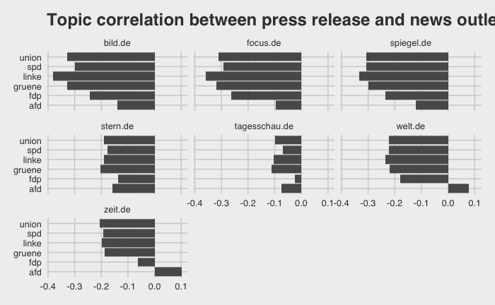

```r
ggplot(correlations, aes(party, cor)) +
  geom_col() +
  coord_flip() +
  ggthemes::theme_fivethirtyeight() +
  facet_wrap(~medium) +
  labs(x = NULL, y = NULL, title = "Topic correlation between press release and news outlet")
```

```r
estimateBias <- function(party){

  df1 <- correlations %>%
    filter(party == party)

  df2 <- correlations %>%
    filter(party != party) %>%
    group_by(medium) %>%
    summarise(avg_cor = mean(cor))

  tempdf <- left_join(df1,df2) %>%
    mutate(agenda_bias = cor-avg_cor,
           agenda_bias_norm = normalize_data2(agenda_bias))

  return(tempdf)

}
```

```r
parties <- unique(correlations$party)
for (i in parties) {

    df1 <- correlations %>% filter(party == i)

    df2 <- correlations %>%
      filter(party != i) %>%
      group_by(medium) %>%
      summarise(avg_cor = mean(cor))

    tempdf <- left_join(df1,df2, by="medium") %>%
      mutate(agenda_bias = cor-avg_cor,
             agenda_bias_norm = normalize_data2(agenda_bias)
             )

    if (exists('agendaBias')){
      agendaBias <- bind_rows(agendaBias,tempdf)
    } else {
      agendaBias <- tempdf
    }
}
```

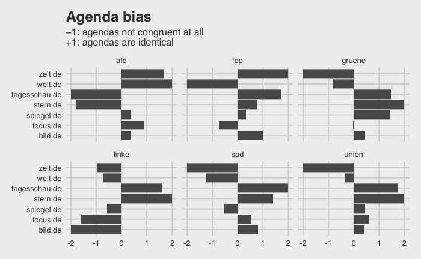

```r
ggplot(agendaBias, aes(medium, agenda_bias_norm)) +
  geom_col() +
  coord_flip() +
  ggthemes::theme_fivethirtyeight() +
  facet_wrap(~party) +
  labs(x = NULL, y = NULL, title = "Agenda bias",
       subtitle = "−1: agendas not congruent at all\n+1: agendas are identical")
```

This underlines the importance of studying all three types of media biases simultane- ously, as examining just one aspect provides a misleading picture of the extent and nature of bias. The existence of various and diverse forms of media bias also means that it is worth considering their distinct effects on party preferences.